# Paper-plots

# 20 Fig 2G 5mC at Mtus1

```r
ensdb <- ah[["AH89457"]]
```

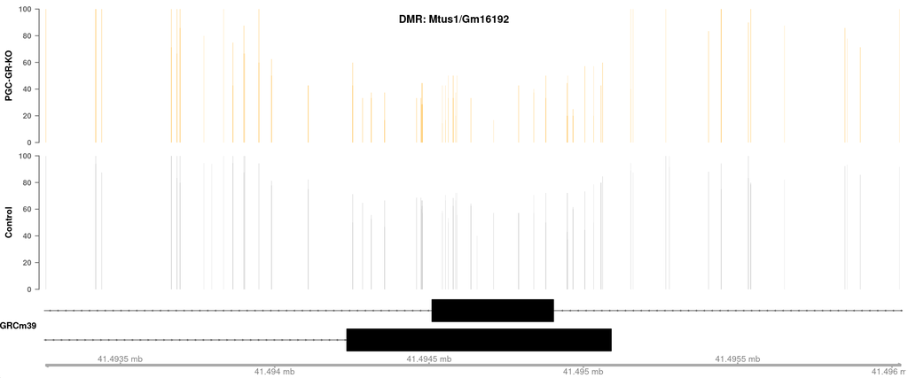

```r
plotSignalTracks(files = list("PGC-GR-KO"=methyl_bw[c(3,4)],Control =methyl_bw[c(1,2)]),overlay.alpha = 75,region = "8: 41494253-41495035",aggregation = "overlay",colors = c("orange","darkgrey"),genomeAxis = T,ensdb = ensdb,extend = c(1000,1000),ylim= c(0,100), fontface.main = 1,cex.main = 1,cex.id=0.9,cex.title = 0.7) # , rotation.title = 0
grid.text(paste0("DMR: Mtus1/Gm16192"), x = 0.5, y = 0.95, gp = gpar(fontsize = 10, fontface = "bold"))
```

```r
png(paste0("plots/Fig2G.png"), width=750, height=512)
plotSignalTracks(files = list("PGC-GR-KO"=methyl_bw[c(3,4)],Control =methyl_bw[c(1,2)]),overlay.alpha = 75,region = "8: 41494253-41495035",aggregation = "overlay",colors = c("orange","darkgrey"),genomeAxis = T,ensdb = ensdb,extend = c(1000,1000),ylim= c(0,100), fontface.main = 1.4,cex.main = 0.9,cex.id=0.9,cex.title = 0.9) # , rotation.title = 0
grid.text(paste0("DMR: Mtus1/Gm16192"), x = 0.5, y = 0.95, gp = gpar(fontsize = 15, fontface = "bold"))
dev.off()
```

```r
pdf(paste0("plots/Fig2G.pdf"), width=8, height=7,colormodel = "cymk")
plotSignalTracks(files = list("PGC-GR-KO"=methyl_bw[c(3,4)],Control =methyl_bw[c(1,2)]),overlay.alpha = 75,region = "8: 41494253-41495035",aggregation = "overlay",colors = c("orange","darkgrey"),genomeAxis = T,ensdb = ensdb,extend = c(1000,1000),ylim= c(0,100), fontface.main = 1.4,cex.main = 0.9,cex.id=0.9,cex.title = 0.9) # , rotation.title = 0
grid.text(paste0("DMR: Mtus1/Gm16192"), x = 0.5, y = 0.95, gp = gpar(fontsize = 15, fontface = "bold"))
dev.off()
```

```r
svg(paste0("plots/Fig2G.svg"), width=8, height=7)
plotSignalTracks(files = list("PGC-GR-KO"=methyl_bw[c(3,4)],Control =methyl_bw[c(1,2)]),overlay.alpha = 75,region = "8: 41494253-41495035",aggregation = "overlay",colors = c("orange","darkgrey"),genomeAxis = T,ensdb = ensdb,extend = c(1000,1000),ylim= c(0,100), fontface.main = 1.4,cex.main = 0.9,cex.id=0.9,cex.title = 0.9) # , rotation.title = 0
grid.text(paste0("DMR: Mtus1/Gm16192"), x = 0.5, y = 0.95, gp = gpar(fontsize = 15, fontface = "bold"))
dev.off()
```

#Fig 2H 5mC at Promoter of embryo DEA

```r
dea <- readRDS("objects/DEA_e2c.rds")
annGR <- readRDS("objects/annGR.rds")
```

```r
set.seed(1234)
annGR <- readRDS("objects/annGR.rds")
annGR2 <-keepStandardChromosomes(annGR[annGR$gene_name %in% dea$ID,],pruning.mode = "coarse"); annGR <- dropSeqlevels(annGR,value = c("chrMT","X","Y"),pruning.mode = "coarse")
DEA_up <- annGR[annGR$gene_name %in% dea$ID[(dea$FDR < 0.05) & (dea$logFC < 0)] ,]
DEA_up <- keepStandardChromosomes(DEA_up,pruning.mode = "coarse"); DEA_up <- dropSeqlevels(DEA_up,value = c("chrMT","X","Y"),pruning.mode = "coarse")
DEA_up <- GenomicRanges::reduce(DEA_up)



DEA_down <- annGR[annGR$gene_name %in% dea$ID[(dea$FDR < 0.05) & (dea$logFC > 0)] ,]
DEA_down <- keepStandardChromosomes(DEA_down,pruning.mode = "coarse"); DEA_down <- dropSeqlevels(DEA_down,value = c("chrMT","X","Y"),pruning.mode = "coarse")
DEA_down <- GenomicRanges::reduce(DEA_down)
DEA_down <- sample(DEA_down,size = length(DEA_up))


DEA <- unlist(GRangesList(DEA_up,DEA_down))



# we remove random promoters which have now overlap with any methylData
annGR2 <- annGR2[overlapsAny(annGR2,unlist(GRangesList(methyl_bed)))]

randDEA <- sample(GenomicRanges::reduce(annGR2[!overlapsAny(annGR2,DEA),]),length(DEA_up))

DEA2 <- unlist(GRangesList(DEA_up,DEA_down,randDEA))

DEA <- resize(DEA,width = 2,fix = "start")
DEA2 <- resize(DEA2,width = 2,fix = "start")


# sanity check
#proms <- promoters(ensdb,upstream = 5,downstream = 5)

#overlapsAny(DEA2,proms)
```

```r
k <- integer(length(DEA2))
k[1:(length(DEA_up))] <- "PGC-GR-KO\nearlyEmbryo UP"
k[((length(DEA_up))+1):(length(DEA_up)+length(DEA_down))] <- "PGC-GR-KO\nearlyEmbryo DOWN"
k[(((length(DEA_up)+length(DEA_down)))+1):length(DEA2)] <- "randomProms"
```

```r
i <- integer(length(DEA))
i[1:(length(DEA_up))] <- "PGC-GR-KO\nearlyEmbryo UP"
i[((length(DEA_up))+1):length(DEA)] <- "PGC-GR-KO\nearlyEmbryo DOWN"
```

```r
sm1 <- signal2Matrix(filepaths = methyl_bed,w = 1,regions = DEA2,smooth = T,limit = c(0,100),extend = c(500,1500))

plotEnrichedHeatmaps(sm1)
```

```r
melt <- meltSignals(sm1,splitBy = k)
melt$Group <- melt$split
```

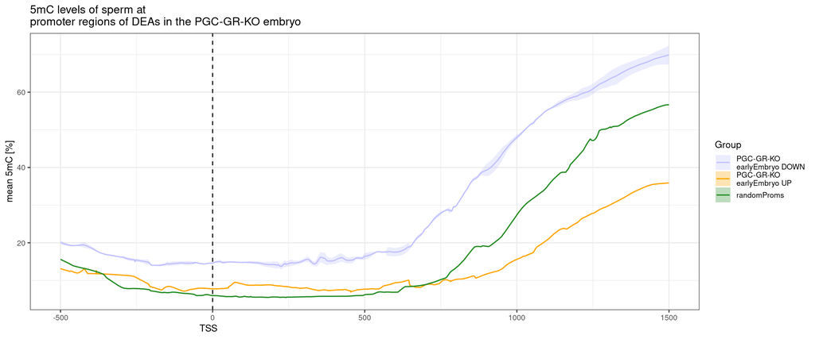

```r
theme_set(theme_bw())
ggplot(melt, aes(position, mean, colour=Group, group = Group, fill = Group)) +
  geom_vline(xintercept=0, linetype="dashed") +
  labs(x="TSS", y="mean 5mC [%]")+
  stat_summary(geom="ribbon", alpha=0.3, colour = NA ) + stat_summary(fun=median, geom="line", size = 0.6)+
  ggtitle("5mC levels of sperm at\npromoter regions of DEAs in the PGC-GR-KO embryo")+
  scale_color_manual(values = c("#c0c0ffff","#ffa500ff","forestgreen")) +
  scale_fill_manual(values = c("#c0c0ffff","#ffa500ff","forestgreen")) +
  theme(text = element_text(size = 10), axis.title.x = element_text(hjust = 0.26))
```

```r
ggsave("plots/Fig2H_Alpl_GR_KO_prompter.svg")
ggsave("plots/Fig2H_Alpl_GR_KO_prompter.pdf")
ggsave("plots/Fig2H_Alpl_GR_KO_prompter.png")
```

```r
melt[melt$split == "randomProms",]
```

|  | split | position | sample | mean | SD | SE | median | Group |
| --- | --- | --- | --- | --- | --- | --- | --- | --- |
| 16009 | randomProms | -500.0000000 | Control 1 | NA | NA | NA | NA | randomProms |
| 16010 | randomProms | -499.0000000 | Control 1 | NA | NA | NA | NA | randomProms |
| 16011 | randomProms | -498.0000000 | Control 1 | NA | NA | NA | NA | randomProms |
| 16012 | randomProms | -497.0000000 | Control 1 | NA | NA | NA | NA | randomProms |
| 16013 | randomProms | -496.0000000 | Control 1 | NA | NA | NA | NA | randomProms |
| 16014 | randomProms | -495.0000000 | Control 1 | NA | NA | NA | NA | randomProms |
| 16015 | randomProms | -494.0000000 | Control 1 | NA | NA | NA | NA | randomProms |
| 16016 | randomProms | -493.0000000 | Control 1 | NA | NA | NA | NA | randomProms |
| 16017 | randomProms | -492.0000000 | Control 1 | NA | NA | NA | NA | randomProms |
| 16018 | randomProms | -491.0000000 | Control 1 | NA | NA | NA | NA | randomProms |

[output cut: 7994 more lines]

## 20.1 AUC

here we use all genes e2c up and down

```r
set.seed(1234)
annGR <- readRDS("objects/annGR.rds")
annGR2 <-keepStandardChromosomes(annGR[annGR$gene_name %in% dea$ID,],pruning.mode = "coarse"); annGR <- dropSeqlevels(annGR,value = c("chrMT","X","Y"),pruning.mode = "coarse")
DEA_up <- annGR[annGR$gene_name %in% dea$ID[(dea$FDR < 0.05) & (dea$logFC < 0)] ,]
DEA_up <- keepStandardChromosomes(DEA_up,pruning.mode = "coarse"); DEA_up <- dropSeqlevels(DEA_up,value = c("chrMT","X","Y"),pruning.mode = "coarse")
DEA_up <- reduce(DEA_up)
```

```
## Error in `getListElement()`:
## ! GRanges objects don't support [[, as.list(), lapply(), or unlist() at the
##   moment
```

```r
DEA_down <- annGR[annGR$gene_name %in% dea$ID[(dea$FDR < 0.05) & (dea$logFC > 0)] ,]
DEA_down <- keepStandardChromosomes(DEA_down,pruning.mode = "coarse"); DEA_down <- dropSeqlevels(DEA_down,value = c("chrMT","X","Y"),pruning.mode = "coarse")
DEA_down <- reduce(DEA_down)
```

```
## Error in `getListElement()`:
## ! GRanges objects don't support [[, as.list(), lapply(), or unlist() at the
##   moment
```

```r
#DEA_down <- sample(DEA_down,size = length(DEA_up))


DEA <- unlist(GRangesList(DEA_up,DEA_down))



# we remove random promoters which have now overlap with any methylData
annGR2 <- annGR2[overlapsAny(annGR2,unlist(GRangesList(methyl_bed)))]

randDEA <- sample(reduce(annGR2[!overlapsAny(annGR2,DEA),]),length(DEA_up))
```

```
## Error in `h()`:
## ! error in evaluating the argument 'x' in selecting a method for function 'sample': GRanges objects don't support [[, as.list(), lapply(), or unlist() at the
##   moment
```

```r
DEA2 <- unlist(GRangesList(DEA_up,DEA_down,randDEA))

DEA <- resize(DEA,width = 2,fix = "start")
DEA2 <- resize(DEA2,width = 2,fix = "start")
```

```r
k <- integer(length(DEA2))
k[1:(length(DEA_up))] <- "PGC-GR-KO\nearlyEmbryo UP"
k[((length(DEA_up))+1):(length(DEA_up)+length(DEA_down))] <- "PGC-GR-KO\nearlyEmbryo DOWN"
k[(((length(DEA_up)+length(DEA_down)))+1):length(DEA2)] <- "randomProms"
```

```r
i <- integer(length(DEA))
i[1:(length(DEA_up))] <- "PGC-GR-KO\nearlyEmbryo UP"
i[((length(DEA_up))+1):length(DEA)] <- "PGC-GR-KO\nearlyEmbryo DOWN"
```

```r
sm1 <- signal2Matrix(filepaths = methyl_bed,w = 1,regions = DEA,smooth = T,limit = c(0,100),extend = c(500,1500))
# for proper calculations we ensure to remove regions where smoothing failed
sm1[is.na(as.data.frame(assay(sm1)))]
```

```
## Error in `x[i, , drop = FALSE]`:
## ! (subscript) logical subscript too long
```

```r
rows_with_na <- apply(as.data.frame(assay(sm1)), 1, function(row) any(is.na(row)))
sm1_clean <- sm1[!rows_with_na,]
i_clean <- i[!rows_with_na]
```

```r
plotEnrichedHeatmaps(sm1_clean)
# assay(sm1_clean)
sm1_clean_merged <- mergeSignalMatrices(sm1_clean)
df <- as.data.frame(sm1_clean_merged)
df <- df[,501:ncol(df)]
```

```r
AUC_per_region <- sapply(1:nrow(df),function(row){
  sm_auc(x =1:length(unlist(c(df[row,]))) , y =unlist(c(df[row,])))
})


mean(AUC_per_region[i_clean == "PGC-GR-KO\nearlyEmbryo DOWN"])/mean(AUC_per_region[i_clean == "PGC-GR-KO\nearlyEmbryo UP"])
```

```
## [1] 2.334596
```

```r
median(AUC_per_region[i_clean == "PGC-GR-KO\nearlyEmbryo DOWN"])/median(AUC_per_region[i_clean == "PGC-GR-KO\nearlyEmbryo UP"])
```

```
## [1] 8.459695
```

```r
library(coin)
coin_wilcox <- coin::wilcox_test(AUC_per_region ~as.factor(i_clean),distribution=approximate(nresample = 10000))
  pvalue_wilcox <- pvalue(coin_wilcox)
  sigma_wilcox <- statistic(coin_wilcox)
```

```r
melt <- meltSignals(sm1_clean,splitBy = i_clean)
melt$Group <- melt$split

melt_UP <- melt[melt$split == "PGC-GR-KO\nearlyEmbryo UP",]
melt_DOWN <- melt[melt$split == "PGC-GR-KO\nearlyEmbryo DOWN",]
```

```r
mean_data_up <- melt_UP %>%
  group_by(position) %>%
  summarize(mean_y = mean(mean))


mean_data_down <- melt_DOWN %>%
  group_by(position) %>%
  summarize(mean_y = mean(mean))


x_min <- 0
x_max <- 1500



filtered_data_up <- mean_data_up %>%
  filter(position >= x_min & position <= x_max)
```

```
## Error in `filter()`:
## ! ensembldb::filter requires an 'EnsDb' object as input. To call the filter function from the stats or dplyr package use stats::filter and dplyr::filter instead.
```

```r
filtered_data_down <- mean_data_down %>%
  filter(position >= x_min & position <= x_max)
```

```
## Error in `filter()`:
## ! ensembldb::filter requires an 'EnsDb' object as input. To call the filter function from the stats or dplyr package use stats::filter and dplyr::filter instead.
```

```r
library(smplot2)
up_auc <- sm_auc(filtered_data_up$position,filtered_data_up$mean_y)
```

```
## Error:
## ! object 'filtered_data_up' not found
```

```r
down_auc <- sm_auc(filtered_data_down$position,filtered_data_down$mean_y)
```

```
## Error:
## ! object 'filtered_data_down' not found
```

```r
down_auc/up_auc
```

```
## Error:
## ! object 'down_auc' not found
```

# 21 Fig S2C - DMRs with GR track

```r
bw <- list.files(path = "intern_data/ChIP/",pattern = "*.bw$",full.names = T)
names(bw) <- basename(bw)

bw <- bw[!grepl(pattern = "Input|Stress",bw)]





GR_bed <- sapply(names(bw),function(names){
  import.bw(bw[names])
})
```

```r
HyperDMR <- readRDS("objects/hyper_mm39.rds")
HypoDMR <- readRDS("objects/hypo_mm39.rds")

DMR <- unlist(GRangesList(HyperDMR,HypoDMR))
```

```r
sm_GR_5mC <- signal2Matrix(regions = DMR,filepaths =  GR_bed,type = "scaled")
sm_merge_GR_5mC <- mergeSignalMatrices(epiwraps:::.ese2ml(sm_GR_5mC))

names(sm_merge_GR_5mC) <- "GR"
```

```r
plotEnrichedHeatmaps(sm_merge_GR_5mC,row_title = "DMR",scale_title = "GRdensity", color = mako(2000))
```

[output not shown]

```r
p_GR1 <-  plotEnrichedHeatmaps( list(GR =sm_merge_GR_5mC),row_title = "DMR",scale_title = "GR\ndesnity",colors = mako(2000), raster_resize_mat = TRUE, use_raster = TRUE, trim = c(0.01,0.99),width = unit(0.8,"npc"), heatmap_legend_param = list(legend_direction = "horizontal", legend_width = unit(0.2,"npc"), title=NULL))


#p_GR1

#p_GR2 <-  plotEnrichedHeatmaps(sn_GR,row_title = "GR-ChIP sites",scale_title = "GR\ndesnity",colors = c("black","steelblue1"),mean_scale_side = "none", raster_resize_mat = TRUE, axis_name = c("-2kb","0","+2kb"),trim = c(0.005,0.995), heatmap_legend_param = list(legend_direction = "horizontal", legend_width = unit(0.28, "npc"), title=NULL))

#p_GR2

  draw(p_GR1, heatmap_legend_side="bottom", annotation_legend_side="right",  legend_grouping = "original")

  png(paste0("sup_plots/FigS2Cnew.png"), width=500, height=1000)
  draw(p_GR1, heatmap_legend_side="bottom", annotation_legend_side="right",  legend_grouping = "original")
  dev.off()
```

```r
  pdf(paste0("sup_plots/FigS2Cnew.pdf"), width=2.5, height=5)
  draw(p_GR1, heatmap_legend_side="bottom", annotation_legend_side="right",  legend_grouping = "original")
  dev.off()
```

```r
  svg(paste0("sup_plots/FigS2Cnew.svg"), width=2.5, height=5)
  draw(p_GR1, heatmap_legend_side="bottom", annotation_legend_side="right",  legend_grouping = "original")
  dev.off()
```

# 22 Fig S2E - DEAs PGC-GR-KO early embryo RegionUpset

```r
df <- read.csv("objects/DEAFDR005-VF-KO.csv", sep = ";")
# Create a list of vectors, each vector represents a category
sperm_overlaps <- df$Gene[df$Overlap.sperm.ATAC == 1]
gre <- df$Gene[df$GRE.in.gene == 1]
motifs <- df$Gene[df$gene.body.motifs.connected.to.GR == 1]

gene_list <- list(DEGs = df$Gene, "DEGs accesible in Sperm" = sperm_overlaps, "DEGs with GRE motif" = gre, "DEGs with GR binding partner motif" = motifs)
```

```r
png(paste0("sup_plots/FigS2E.png"),width=8, height=7,res = 300,units = "in")
regionUpset2(gene_list)
dev.off()
```

```r
pdf(paste0("sup_plots/FigS2E.pdf"), width=8, height=7,colormodel = "cymk")
regionUpset2(gene_list)
dev.off()
```

```r
svg(paste0("sup_plots/FigS2E.svg"), width=8, height=7)
regionUpset2(gene_list)
dev.off()
```

# 23 Fig S2F - GSEA PGC-GR-KO

```r
deaGO <- function(dea, threshold=0.05, direction=NULL, ontology="BP"){
  isDE <- dea$adj.P.Val<threshold
  if(!is.null(direction)) isDE <- isDE & sign(dea$logFC)==sign(direction)
  isDE <- setNames(factor(as.integer(isDE)),row.names(dea))
  print(table(isDE))
  god <- new("topGOdata", ontology=ontology, allGenes=isDE,
             nodeSize=10, annot=annFUN.org,
             ID="symbol", mapping="org.Mm.eg.db")
  ea <- runTest(god, algorithm="classic", statistic="fisher")
  res <- GenTable(god, classicFisher=ea, topNodes=length(god@graph@nodes))
  res$Term2 <- plgINS::breakStrings(res$Term)
  res$log2Enrichment <- log2(res$Significant/res$Expected)
  res$FDR <- p.adjust(res$classicFisher)
  res
}

deaGSEA <- function(dea, gsets = NULL){
  if(is.null(gsets))
    # gsets <- plgINS::getMsigSets(species = "Mus musculus", collections=c("H","C5"))

  db <- msigdbr::msigdbr(species = "mouse")
 db <- db[which(db$gs_collection %in% c("H", "C5")),]
gsets <- split(db$gene_symbol, db$gs_name)


    signature <- setNames(sign(dea$logFC)*-log10(dea$P.Value), row.names(dea))
  fg <- fgseaMultilevel(gsets, signature, minSize=10, nproc=3)
  fg$genes <- sapply(fg$leadingEdge, collapse=", ", FUN=paste)
  fg$leadingEdge <- NULL
  as.data.frame(fg[order(fg$pval),])
}
```

```r
se <- readRDS("objects/VF_2cell_embyro_early_paternal_GR_KO(Alpl).SE.rds")
deas <- getDEA(se)
dea <- deas$glmFit
dea$P.Value <- dea$PValue

dea2 <- dea %>% distinct(ID, .keep_all = TRUE)
rownames(dea2) <- dea2$ID

res2 <- deaGSEA(dea = dea2)
```

[output not shown]

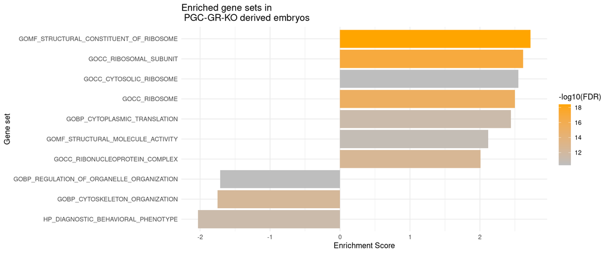

```r
ggplot(head(res2,10), aes(x = reorder(pathway, NES), y = NES, fill = -log10(padj))) +
  geom_bar(stat = "identity") +
  coord_flip() +
  scale_fill_gradient(low = "grey", high = "orange") +
  theme_minimal() +
  labs(
    title = "Enriched gene sets in \n PGC-GR-KO derived embryos",
    x = "Gene set",
    y = "Enrichment Score",
    fill = "-log10(FDR)"
  )
```

```r
ggsave("./sup_plots/FigS2F_GSEA_KO.svg")
ggsave("./sup_plots/FigS2F_GSEA_KO.pdf")
ggsave("./sup_plots/FigS2F_GSEA_KO.png")
```

# 24 Fig S2G - Gene expression of Nr3c1 in early embryo og PGC-GR-KO sperm

```r
se <- readRDS("objects/VF_2cell_embyro_early_paternal_GR_KO(Alpl).SE.rds")
se$condition <- as.character(se$condition)
se$condition[se$condition == "Early_GR_KO"] <- "PGC-GR-KO"
se$condition[se$condition == "Ctrl"] <- "Control"
se$condition <- as.factor(se$condition)
```

```r
df <- as.data.frame(cbind(t(assays(se)$logcpm),colData(se))) # we extract data from the SE object and combine it with the colData as a dataframe, this makes it more easy to be accessed by ggplot

colnames(df) <- gsub(x = colnames(df),pattern = "^EN(.*)\\.",replacement = "")

df <- df[,!duplicated(colnames(df))]
```

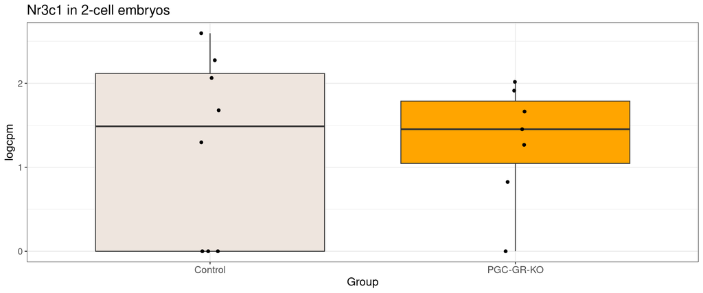

```r
y <- 37.5
e <- ggplot(df, aes(x = condition, y = df$Nr3c1 , fill = df$condition))


 e2 <- e + geom_boxplot(width = 0.75,outlier.shape = NA ) +
   geom_jitter(
   position=position_jitterdodge(jitter.width = 0.1, dodge.width = 0.75),
  # aes(color = df$batch)
    )+
   ylab("logcpm")+
   xlab("Group")+
   ggtitle("Nr3c1 in 2-cell embryos")+

   scale_fill_manual(values=c( "seashell2","#ffa500ff"))+ #c( "seashell2","#ffa500ff","seashell4","tomato3")

   labs(fill= "")+
   scale_x_discrete(labels = c("Ctrl" = "Control", "Early_GR_KO" = "PGC-GR-KO"))+

 theme(
  axis.text.x = element_text(size = 12),
  text = element_text(size = 14),
  legend.position = "none", # Change font size of all text

)
  print(e2)
```

```r
ggsave("sup_plots/FigS2G_Boxplot_Nr3c1.svg")
ggsave("sup_plots/FigS2G_Boxplot_Nr3c1.pdf")
ggsave("sup_plots/FigS2G_Boxplot_Nr3c1.png")
```

# 25 Fig S2I - Tracks for Rdx and Ptp4a2

```r
png(paste0("sup_plots/FigS2I_Rdx.png"), width=750, height=512)
plotSignalTracks(files = list("PGC-GR-KO"=methyl_bw[c(3,4)],Control =methyl_bw[c(1,2)]),overlay.alpha = 75,region = "9:52011472-52012171",aggregation = "overlay",colors = c("orange","darkgrey"),genomeAxis = T,ensdb = ensdb,extend = c(1000,1000),ylim= c(0,100), fontface.main = 1.4,cex.main = 0.9,cex.id=0.9,cex.title = 0.9) # , rotation.title = 0
grid.text(paste0("DMR: Rdx"), x = 0.5, y = 0.95, gp = gpar(fontsize = 15, fontface = "bold"))
dev.off()
```

```r
pdf(paste0("sup_plots/FigS2I_Rdx.pdf"), width=8, height=7,colormodel = "cymk")
plotSignalTracks(files = list("PGC-GR-KO"=methyl_bw[c(3,4)],Control =methyl_bw[c(1,2)]),overlay.alpha = 75,region = "9:52011472-52012171",aggregation = "overlay",colors = c("orange","darkgrey"),genomeAxis = T,ensdb = ensdb,extend = c(1000,1000),ylim= c(0,100), fontface.main = 1.4,cex.main = 0.9,cex.id=0.9,cex.title = 0.9) # , rotation.title = 0
grid.text(paste0("DMR: Rdx"), x = 0.5, y = 0.95, gp = gpar(fontsize = 15, fontface = "bold"))
dev.off()
```

```r
svg(paste0("sup_plots/FigS2I_Rdx.svg"), width=8, height=7)
plotSignalTracks(files = list("PGC-GR-KO"=methyl_bw[c(3,4)],Control =methyl_bw[c(1,2)]),overlay.alpha = 75,region = "9:52011472-52012171",aggregation = "overlay",colors = c("orange","darkgrey"),genomeAxis = T,ensdb = ensdb,extend = c(1000,1000),ylim= c(0,100), fontface.main = 1.4,cex.main = 0.9,cex.id=0.9,cex.title = 0.9) # , rotation.title = 0
grid.text(paste0("DMR: Rdx"), x = 0.5, y = 0.95, gp = gpar(fontsize = 15, fontface = "bold"))
dev.off()
```

```r
png(paste0("sup_plots/FigS2I_Ptp4a2.png"), width=750, height=512)
plotSignalTracks(files = list("PGC-GR-KO"=methyl_bw[c(3,4)],Control =methyl_bw[c(1,2)]),overlay.alpha = 75,region = "4: 129711699-129711894",aggregation = "overlay",colors = c("orange","darkgrey"),genomeAxis = T,ensdb = ensdb,extend = c(1000,1000),ylim= c(0,100), fontface.main = 1.4,cex.main = 0.9,cex.id=0.9,cex.title = 0.9) # , rotation.title = 0
grid.text(paste0("DMR: Ptp4a2"), x = 0.5, y = 0.95, gp = gpar(fontsize = 15, fontface = "bold"))
dev.off()
```

```r
pdf(paste0("sup_plots/FigS2I_Ptp4a2.pdf"), width=8, height=7,colormodel = "cymk")
plotSignalTracks(files = list("PGC-GR-KO"=methyl_bw[c(3,4)],Control =methyl_bw[c(1,2)]),overlay.alpha = 75,region = "4: 129711699-129711894",aggregation = "overlay",colors = c("orange","darkgrey"),genomeAxis = T,ensdb = ensdb,extend = c(1000,1000),ylim= c(0,100), fontface.main = 1.4,cex.main = 0.9,cex.id=0.9,cex.title = 0.9) # , rotation.title = 0
grid.text(paste0("DMR: Ptp4a2"), x = 0.5, y = 0.95, gp = gpar(fontsize = 15, fontface = "bold"))
dev.off()
```

```r
svg(paste0("sup_plots/FigS2I_Ptp4a2.svg"), width=8, height=7)
plotSignalTracks(files = list("PGC-GR-KO"=methyl_bw[c(3,4)],Control =methyl_bw[c(1,2)]),overlay.alpha = 75,region = "4: 129711699-129711894",aggregation = "overlay",colors = c("orange","darkgrey"),genomeAxis = T,ensdb = ensdb,extend = c(1000,1000),ylim= c(0,100), fontface.main = 1.4,cex.main = 0.9,cex.id=0.9,cex.title = 0.9) # , rotation.title = 0
grid.text(paste0("DMR: Ptp4a2"), x = 0.5, y = 0.95, gp = gpar(fontsize = 15, fontface = "bold"))
dev.off()
```

# 26 Fig 3A

```r
peak <- import("objects/NFpeaks/embryo_consensus.bed")
```

```
## Error in `open.connection()`:
## ! cannot open the connection
```

```r
# length(peak)

peak_seqs <- memes::get_sequence(peak, genome)
```

```
## Error:
## ! object 'peak' not found
```

```r
length(peak_seqs)
```

```
## [1] 32027
```

```r
ame <- runAme(peak_seqs, database=convert_motifs(motifs), meme_path="/common/meme/bin") #https://meme-suite.org/meme/doc/ame-output-format.html
```

```
## Error:
## ! unable to find an inherited method for function 'convert_motifs' for signature 'motifs = "integer"'
```

```r
# ame[1:10]
```

```r
ame <- readRDS("objects/ame_embryo_consensus.rds")
# ame[1:10]
gr <- ame[82, , drop=TRUE]
```

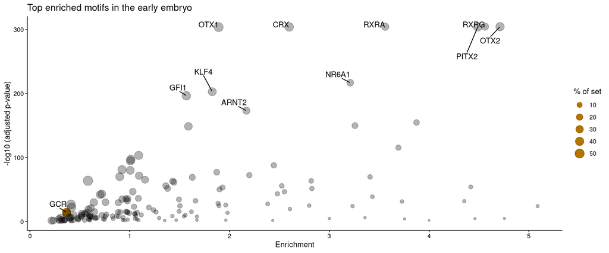

```r
ggplot(ame, aes(log2((1+tp)/(1+fp)), -log10(adj.pvalue))) +
  geom_point(data=gr, aes(size=tp_percent), color="orange")+
  geom_text_repel(box.padding=0.5, min.segment.length = 0, max.overlaps = 10,  nudge_y = 0.3, direction = "y", hjust = "right", aes(label=motif_id ), data= gr)+
  geom_point(aes(size=tp_percent), alpha=0.3) +
  geom_text_repel(box.padding=0.5, min.segment.length = 0, max.overlaps = 10,  nudge_y = 0.3, direction = "y", hjust = "right", aes(label=motif_id ), data= head(ame,10))+
  labs(x="log2(fold-enrichment)", size="% of set")+
  ylab("-log10 (adjusted p-value)")+
  xlab("Enrichment")+
  theme_classic() +
  ggtitle("Top enriched motifs in the early embryo")+
  guides(fill = guide_legend(override.aes = aes(color = NA)))
```

```r
ggsave("./plots/Fig3A_motif_enrichment_embryo_highconfidencepeaks.svg")
ggsave("./plots/Fig3A_motif_enrichment_embryo_highconfidencepeaks.pdf")
ggsave("./plots/Fig3A_motif_enrichment_embryo_highconfidencepeaks.png")
```

# 27 Fig 3B - Clustering GRE peaks

```r
tracks <- c(
  sperm1="extern_data/ATAC_PRJNA480448_Sperm_GSM3262855.bw",
  sperm2="extern_data/ATAC_PRJNA480448_Sperm_GSM3262856.bw",
  sperm3="extern_data//ATAC_PRJNA315208_Sperm_GSM2088377.bw",
  sperm4="extern_data//ATAC_PRJNA315208_Sperm_GSM2088378.bw",
  MIIoocyte1="extern_data/ATAC_PRJNA480448_MIIOocyte_GSM3262863.bw",
  embryoearly2cell="extern_data/ATAC_PRJNA277362_Early2cell_merged.bw",
  embryo2cell="extern_data/ATAC_PRJNA277362_2cell_merged.bw",
  embryo4cell="extern_data/ATAC_PRJNA277362_4cell_merged.bw",
  ESC="extern_data/ATAC_PRJNA277362_ESC_GSM1625858.bw"
  )
```

```r
mycolors <- c("1"=brewer.pal(n=20,"Set1")[1], "2"=brewer.pal(n=20,"Set1")[2], "3"=brewer.pal(n=20,"Set1")[3], "4"=brewer.pal(n=20,"Set1")[4], "5"=brewer.pal(n=20,"Set1")[5], "6"=brewer.pal(n=20,"Set1")[6], "7"=brewer.pal(n=20,"Set1")[7], "8"=brewer.pal(n=20,"Set1")[8],
              "9"=brewer.pal(n=20,"Paired")[1], "10"=brewer.pal(n=20,"Paired")[2], "11"=brewer.pal(n=20,"Paired")[3], "12"=brewer.pal(n=20,"Paired")[4], "13"=brewer.pal(n=20,"Paired")[5], "14"=brewer.pal(n=20,"Paired")[6], "15"=brewer.pal(n=20,"Paired")[7], "16"=brewer.pal(n=20,"Paired")[8], "17"=brewer.pal(n=20,"Paired")[9], "18"=brewer.pal(n=20,"Paired")[10], "19"=brewer.pal(n=20,"Paired")[11])

set.seed(123)

peaks_emb <- readRDS("./objects/peaks_with_GRE_embryo_inAny.rds")
peaks_sperm <- readRDS("./objects/narrow_peaks_with_GRE_sperm.rds")
peaks_oo <- readRDS("./objects/narrow_peaks_with_GRE_mIIoocytes.rds")

length(peaks_emb) #2084
```

```
## [1] 2084
```

```r
length(peaks_sperm) #9311
```

```
## [1] 9311
```

```r
length(peaks_oo) #792
```

```
## [1] 792
```

```r
peaks_emb <- reduce(peaks_emb, with.revmap=TRUE)
```

```
## Error in `getListElement()`:
## ! GRanges objects don't support [[, as.list(), lapply(), or unlist() at the
##   moment
```

```r
length(peaks_emb)
```

```
## [1] 2084
```

```r
peaks_sperm <- reduce(peaks_sperm, with.revmap=TRUE)
```

```
## Error in `getListElement()`:
## ! GRanges objects don't support [[, as.list(), lapply(), or unlist() at the
##   moment
```

```r
length(peaks_sperm)
```

```
## [1] 9311
```

```r
peaks_oo <- reduce(peaks_oo, with.revmap=TRUE)
```

```
## Error in `getListElement()`:
## ! GRanges objects don't support [[, as.list(), lapply(), or unlist() at the
##   moment
```

```r
length(peaks_oo)
```

```
## [1] 792
```

```r
peaklist <- unlist(GRangesList(peaks_emb, peaks_sperm, peaks_oo))
length(peaklist) #12117
```

```
## [1] 12187
```

```r
m <- signal2Matrix(tracks, peaklist, w=5, type="center",  BPPARAM = 4)
```

[output not shown]

```r
m <- epiwraps:::.ese2ml(m)

fused_sperm_mat <- mergeSignalMatrices(m[1:4])
fused_m <- c(list(sperm=fused_sperm_mat), m[5:9], m[-1:-9])
fused_n <- renormalizeBorders(lapply(fused_m,log1p))

# fused_m <- readRDS("objects/clustering_fused_m.rds")
# fused_n <- readRDS("objects/clustering_fused_n.rds")

cl <- clusterSignalMatrices(fused_n, k=9) #% variance explained by clusters
ro <- order(rowMeans(fused_n$embryoearly2cell), decreasing = TRUE)
```

```r
pdf("plots/Fig3B_GREpeaks_clustering.pdf", width=14.5, height=10)
x <- plotEnrichedHeatmaps(fused_n,
                     row_split = cl,
                     row_order = ro,
                     #trim = 0.99,
                     raster_resize_mat = FALSE,
                     mean_color = mycolors,
                     scale_rows = FALSE,
                     axis_name = c("-2kb","0","+2kb")
                     )
print(x)
dev.off()
```

```r
png("plots/Fig3B_GREpeaks_clustering.png", height=768)
x <- plotEnrichedHeatmaps(fused_n,
                     row_split = cl,
                     row_order = ro,
                     #trim = 0.99,
                     raster_resize_mat = FALSE,
                     mean_color = mycolors,
                     scale_rows = FALSE,
                     axis_name = c("-2kb","0","+2kb")
                     )
print(x)
dev.off()
```

# 28 Fig 3D - 2-cell SmartSeq

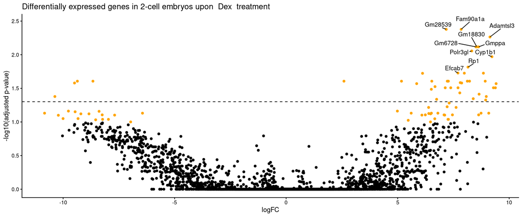

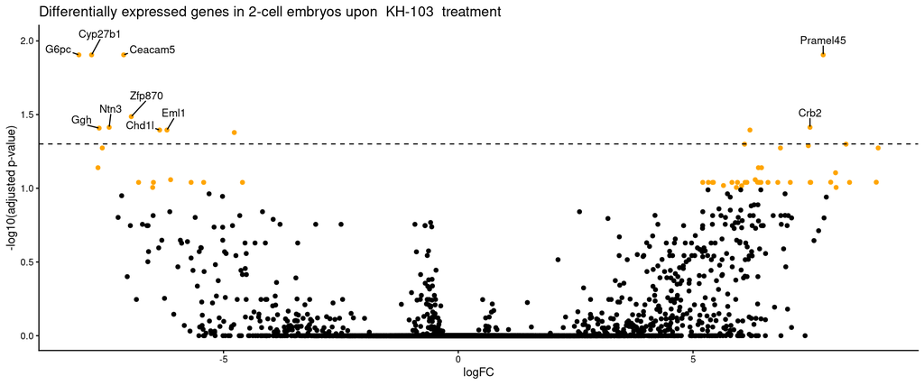

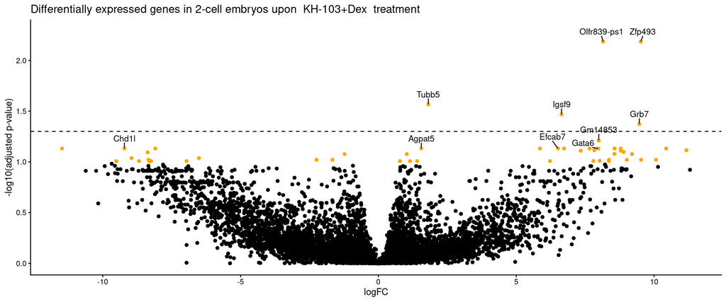

```r
se <- readRDS("objects/MK_EXP20.1_ProtacEmbryo_merged.SE.rds")

# Generate the dataframes
dex <- rowData(se)[[4]]
protac <- rowData(se)[[3]]
pd <- rowData(se)[[5]]

protac$Gene <- rownames(protac)
dex$Gene <- rownames(dex)
pd$Gene <- rownames(pd)

# List of dataframes
df_list <- list(Dex = dex, "KH-103" = protac, "KH-103+Dex" = pd)

# Function to generate volcano plots
generate_volcano_plot <- function(df, title) {
  df$highlight <- df$FDR < 0.1
  top_genes <- df[order(df$FDR), ][1:10, ]
  ggplot(df, aes(x=logFC, y=-log10(FDR))) +
    geom_point(aes(color = highlight)) +
    scale_color_manual(values = c("TRUE" = "orange", "FALSE" = "black")) +
    geom_text_repel(data = subset(top_genes, highlight == TRUE), aes(label=Gene), size=3.5, min.segment.length = 0, max.overlaps = Inf, nudge_y = 0.1) +
    geom_hline(yintercept=-log10(0.05), linetype="dashed")+
    xlab("logFC") +
    ylab("-log10(adjusted p-value)") +
    theme_classic() +
    theme(legend.position="none") +
    ggtitle(title)
}

# Apply the function to each dataframe in the list
plots <- lapply(names(df_list), function(name) {
  generate_volcano_plot(df_list[[name]], paste("Differentially expressed genes in 2-cell embryos upon ", name, " treatment"))
})

print(plots)
```

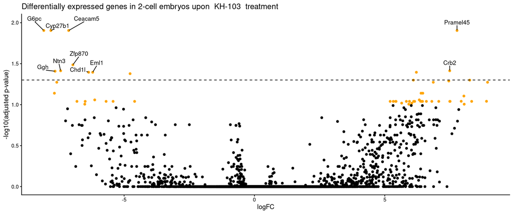

```r
# print(plots[1])
#   ggsave("plots//DEGs_EXP20-1_Dex_volcano.svg")
# ggsave("plots/DEGs_EXP20-1_Dex_volcano.pdf")
# ggsave("plots/DEGs_EXP20-1_Dex_volcano.png")

print(plots[2])
```

```r
ggsave("plots/Fig3D_DEGs_EXP20-1_PROTAC_volcano.svg")
ggsave("plots/Fig3D_DEGs_EXP20-1_PROTAC_volcano.pdf")
ggsave("plots/Fig3D_DEGs_EXP20-1_PROTAC_volcano.png")

# print(plots[3])
# ggsave("plots/DEGs_EXP20-1_PD_volcano.svg")
# ggsave("plots/DEGs_EXP20-1_PD_volcano.pdf")
# ggsave("plots/DEGs_EXP20-1_PD_volcano.png")
```

Heatmaps

```r
se <- readRDS("objects/MK_EXP20.1_ProtacEmbryo_merged.SE.rds")
se <- se[, se$treatment != "Dex"]
se <- se[, se$treatment != "PD"]

# Generate the dataframes
protac <- rowData(se)[[3]]
protac$Gene <- rownames(protac)
protacFDR <- subset(protac, protac$FDR <0.1)

treatments <- unique(se$treatment)

# Define own colors
colors <- c("grey", "orange" )#"800080", "grey", "orange", "black")

# Make sure the number of colors matches the number of treatments
if (length(colors) != length(treatments)) {
  stop("Number of colors must match number of treatments")
}

# Create a named vector for color mapping
color_mapping <- setNames(colors, treatments)

# Add color_mapping to the heatmap annotation
ha = HeatmapAnnotation(df = data.frame(treatment = factor(colData(se)$treatment, levels = names(color_mapping))),
                       col = list(treatment = color_mapping))
```

# 29 Fig 3E - 8-cell SmartSeq

```r
se <- readRDS("objects/MK_EXP20.2_ProtacEmbryo8cells.SE.rds")

# Generate the dataframes
dex <- rowData(se)[[2]]
protac <- rowData(se)[[3]]
pd <- rowData(se)[[4]]

protac$Gene <- rownames(protac)
dex$Gene <- rownames(dex)
pd$Gene <- rownames(pd)

# List of dataframes
df_list <- list(Dex = dex, "KH-103" = protac, "KH-103+Dex" = pd)

# Function for volcano plots
generate_volcano_plot <- function(df, title) {
  df$highlight <- df$adj.P.Val < 0.1
  top_genes <- df[order(df$adj.P.Val), ][1:10, ]
  ggplot(df, aes(x=logFC, y=-log10(adj.P.Val))) +
    geom_point(aes(color = highlight)) +
    scale_color_manual(values = c("TRUE" = "orange", "FALSE" = "black")) +
    geom_text_repel(data = subset(top_genes, highlight == TRUE), aes(label=Gene), size=3.5, min.segment.length = 0, max.overlaps = Inf, nudge_y = 1) +
    geom_hline(yintercept=-log10(0.05), linetype="dashed")+
    xlab("logFC") +
    ylab("-log10(adjusted p-value)") +
    theme_classic() +
    theme(legend.position="none") +
    ggtitle(title)
}


# Apply the function to each dataframe in the list
plots <- lapply(names(df_list), function(name) {
  generate_volcano_plot(df_list[[name]], paste("Differentially expressed genes in 8-cell embryos upon ", name, " treatment"))
})
# print(plots[1])
# ggsave("plots/DEGs_EXP20-2_Dex_volcano.svg")
#   ggsave("plots/DEGs_EXP20-2_Dex_volcano.pdf")
# ggsave("plots/DEGs_EXP20-2_Dex_volcano.png")
#
# print(plots[2])
# ggsave("plots/DEGs_EXP20-2_PROTAC_volcano.svg")
# ggsave("plots/DEGs_EXP20-2_PROTAC_volcano.pdf")
# ggsave("plots/DEGs_EXP20-2_PROTAC_volcano.png")
#
# print(plots[3])
# ggsave("plots/DEGs_EXP20-2_PD_volcano.svg")
# ggsave("plots/DEGs_EXP20-2_PD_volcano.pdf")
# ggsave("plots/DEGs_EXP20-2_PD_volcano.png")
```

heatmaps

```r
se <- readRDS("objects/MK_EXP20.2_ProtacEmbryo8cells.SE.rds")
se <- se[, se$treatment != "DEXR"]
se <- se[, se$treatment != "DEX"]
se <- se[, se$treatment != "PDR"]
se <- se[, se$treatment != "PD"]

# Generate the dataframes
protac <- rowData(se)[[3]]
protac$Gene <- rownames(protac)
protacFDR <- subset(protac, protac$adj.P.Val <0.1)


treatments <- unique(se$treatment)

# Define own colors
colors <- c("#DEDFE4", "darkgrey") # "#919297", "#393A3F",)# , "#800080", "black", "yellow", "orange")#232429"

# Make sure the number of colors matches the number of treatments
if (length(colors) != length(treatments)) {
  stop("Number of colors must match number of treatments")
}

# Create a named vector for color mapping
color_mapping <- setNames(colors, treatments)

# Add color_mapping to the heatmap annotation
ha = HeatmapAnnotation(df = data.frame(treatment = factor(colData(se)$treatment, levels = names(color_mapping))),
                       col = list(treatment = color_mapping))

color_palette <- colorRampPalette(c("blue", "black", "orange"))(100)

pdf("plots/Fig3E_DEGs_EXP20-2_PROTAC_heatmap.pdf") #, width=14.5, height=10)
x <- sechm(se, protacFDR, assayName = "log2FC", do.scale = FALSE, top_annotation = ha, row_title="Differentially expressed genes", gaps_at="treatment", hmcols = color_palette, use_raster = TRUE)
print(x)
dev.off()
```

```r
png("plots/Fig3E_DEGs_EXP20-2_PROTAC_heatmap.png", height=768)
x <- sechm(se, protacFDR, assayName = "log2FC", do.scale = FALSE, top_annotation = ha, row_title="Differentially expressed genes", gaps_at="treatment", hmcols = color_palette, use_raster = TRUE)
print(x)
dev.off()
```

```r
#needs title : KH-103 effects on gene regulation in 8-cell embryos

svg("plots/Fig3E_DEGs_EXP20-2_PROTAC_heatmap.svg")
x <- sechm(se, protacFDR, assayName = "log2FC", do.scale = FALSE, top_annotation = ha, row_title="Differentially expressed genes", gaps_at="treatment", hmcols = color_palette, use_raster = TRUE)
print(x)
dev.off()
```

```r
sechm(se, protacFDR, assayName = "log2FC", do.scale = FALSE, top_annotation = ha, row_title="Differentially expressed genes", gaps_at="treatment", hmcols = color_palette, use_raster = TRUE)
```

[output not shown]

Correlation of EXP20.2 target DEGs in 20.1 and Fig S3D - bland-altmann-plot correlation

```r
se <- readRDS("objects/MK_EXP20.1_ProtacEmbryo_merged.SE.rds")

# Generate the dataframes
dex <- rowData(se)[[4]]
protac <- rowData(se)[[3]]
pd <- rowData(se)[[5]]
dex$Gene <- rownames(dex)
protac$Gene <- rownames(protac)
pd$Gene <- rownames(pd)

# Generate dataframes with FDR<0.05 used in this analysis
dexFDR <- subset(dex, dex$FDR <0.05)
protacFDR <- subset(protac, protac$FDR <0.05)
pdFDR <- subset(pd, pd$FDR <0.05)
dexFDR$Gene <- rownames(dexFDR)
protacFDR$Gene <- rownames(protacFDR)
pdFDR$Gene <- rownames(pdFDR)



# Create a list of dataframes and add column Gene to it
df_list <- list(dexFDR = dexFDR, protacFDR = protacFDR, pdFDR = pdFDR)

rEXP20_2 <- readRDS("objects/df_list_FDR01.rds")
rEXP20_2 <- lapply(rEXP20_2, function(df) {
  df$Gene <- rownames(df)
  return(df)
})

# Function to automate the process
process_dataframes <- function(df_name, df_list, rEXP20_2) {
  # Get the dataframe from the list
  df <- df_list[[df_name]]

  # Construct the variable names
  FDR_var <- paste0(df_name, "FDR")

  # Filter the df dataframe to include only the genes that are in rEXP20_2[[FDR_var]]
  df_filtered <- df[df$Gene %in% rEXP20_2[[FDR_var]]$Gene, ]

  # Filter rEXP20_2[[FDR_var]] to include only the genes that are in df_filtered
  rEXP20_2_FDR_filtered <- rEXP20_2[[FDR_var]][rEXP20_2[[FDR_var]]$Gene %in% df_filtered$Gene, ]

  # Merge the two dataframes on the 'Gene' column
  merged <- merge(df_filtered, rEXP20_2_FDR_filtered, by = "Gene")

  # Calculate the correlation of the logFC between the two dataframes
  correlation <- cor.test(merged$logFC.x, merged$logFC.y)

  # Print the correlation
  print(correlation)

  correlation <- cor(merged$logFC.x, merged$logFC.y)

  # Create a scatter plot
  plot <- ggplot(merged, aes(x=logFC.x, y=logFC.y)) +
    geom_point() +
    geom_text_repel(aes(label=Gene)) +  # Add the gene names to the plot
    geom_smooth(method=lm, se=FALSE, color="orange") +
    annotate("text", x = Inf, y = -Inf, label = paste("Correlation:", round(correlation, 4)), vjust = -1.5, hjust = 1.2) +
    xlab(paste("logFC in 2-cell embryos")) +
    ylab(paste("logFC in 8-cell embryos")) +
    theme_classic() +
    ggtitle(paste("Correlation of gene expression changes between 2- and 8- cell embryos"))

  print(plot)
  ggsave("plots/correlation_EXP20-2_EXP20-1_PROTAC.svg")
  ggsave("plots/correlation_EXP20-2_EXP20-1_PROTAC.pdf")
  ggsave("plots/correlation_EXP20-2_EXP20-1_PROTAC.png")


  # Calculate means and differences
  merged$mean <- rowMeans(merged[,c("logFC.x", "logFC.y")])
  merged$difference <- merged$logFC.x - merged$logFC.y

  # Create a Bland-Altman plot
  bland_altman_plot <- ggplot(merged, aes(x=mean, y=difference)) +
    geom_point() +
    geom_text_repel(aes(label=Gene)) +
    geom_smooth(method=lm, se=FALSE, color="orange") +
    xlab(paste("Mean of logFC in 2-cell and 8-cell embryos")) +
    ylab(paste("Difference of logFC in 2-cell and 8-cell embryos")) +
    theme_classic() +
    ggtitle("Correlation of gene expression changes between 2- and 8-cell embryos")

  print(bland_altman_plot)
  ggsave("plots/correlationBAP_EXP20-2_EXP20-1_PROTAC.svg")
  ggsave("plots/correlationBAP_EXP20-2_EXP20-1_PROTAC.pdf")
  ggsave("plots/correlationBAP_EXP20-2_EXP20-1_PROTAC.png")

  return(merged)
}

# Can call this function with the dataframe names and the list of dataframes
df_names <- c("protac") #, "protac", "pd")
df_list <- list(protac = protac) #, protac = protac, pd = pd)

# Apply the function to each dataframe
lapply(df_names, process_dataframes, df_list = df_list, rEXP20_2 = rEXP20_2)
```

[output not shown]

# 30 Fig 3F - regionUpset DEGs in 2cell and 8cell

```r
library(UpSetR)

regionUpset2 <- function (x = NULL, genelist = NULL, returnList = FALSE, ...)
{
    if (!is.null(genelist)) {
        x <- genelist
    }
    if (is.character(x))
        x <- as.list(x)
    stopifnot(length(x) > 1)
    if (is.list(x)) {
        if (is.null(names(x)) && all(unlist(lapply(x, is.character))) &&
            all(lengths(x) == 1))
            names(x) <- unlist(x)
        if (any(unlist(lapply(x, FUN = function(x) {
            if (is.character(x)) {
                if (length(x) != 0) return(TRUE)
                if (!file.exists(x)) return(TRUE)
            }
            FALSE
        })))) {
            stop("`x` should be a named list of character vectors.")
        }
    }
    x <- lapply(x, function(x) as.character(x))
    if (returnList)
        return(x)
    UpSetR::upset(UpSetR::fromList(x), ...)
}
```

```r
df <- read.csv("objects/DEAFDR01-EXP20-1-2-PROTAC.csv", sep = ";")
# Create a list of vectors, each vector represents a category
sperm_overlaps <- df$Gene[df$Overlap.sperm.ATAC == 1]
gre <- df$Gene[df$GRE.in.gene == 1]
motifs <- df$Gene[df$gene.body.motifs.connected.to.GR == 1]

gene_list <- list(DEGs = df$Gene, "DEGs accesible in Sperm" = sperm_overlaps, "DEGs with GRE motif" = gre, "DEGs with GR binding partner motif" = motifs)
```

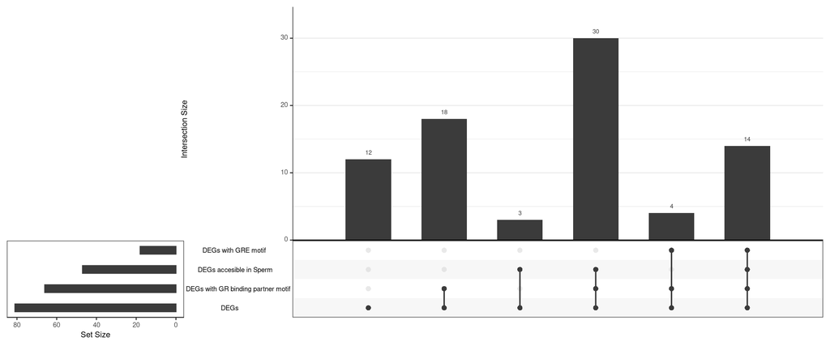

```r
regionUpset2(gene_list)
```

```r
png(paste0("plots/Fig3F.png"), width=8, height=7,res = 300,units = "in")
regionUpset2(gene_list)
dev.off()
```

```r
pdf(paste0("plots/Fig3F.pdf"), width=8, height=7,colormodel = "cymk")
regionUpset2(gene_list)
dev.off()
```

```r
svg(paste0("plots/Fig3F.svg"), width=8, height=7)
regionUpset2(gene_list)
dev.off()
```

# 31 Fig S3A - GO term analysis embryo peaks with GRE

```r
embryo_consensus_peaks <- readRDS("./objects/peaks_with_GRE_embryo_consensus.rds")
seqlevelsStyle(embryo_consensus_peaks) <- "UCSC"
```

Liftover and pruning as GOterm analysis with submitGreatJob can only use mm10 and standard chromosomes

```bash
rsync -avzP rsync://hgdownload.soe.ucsc.edu/goldenPath/mm39/liftOver/mm39ToMm10.over.chain.gz -d ../../../tools/liftOver/
gzip -d ../../../tools/liftOver/mm39ToMm10.over.chain.gz
```

```r
mm39_mm10_chain <- import.chain("objects/mm39ToMm10.over.chain")

embryo_hc_peaks_mm10 <- liftOver(embryo_consensus_peaks, chain = mm39_mm10_chain)
embryo_hc_peaks_mm10 <- unlist(embryo_hc_peaks_mm10)
embryo_hc_peaks_mm10 <- keepStandardChromosomes(embryo_hc_peaks_mm10, pruning.mode = "coarse")
```

```r
length(embryo_consensus_peaks) #110
```

```
## [1] 110
```

```r
length(embryo_hc_peaks_mm10) #108
```

```
## [1] 108
```

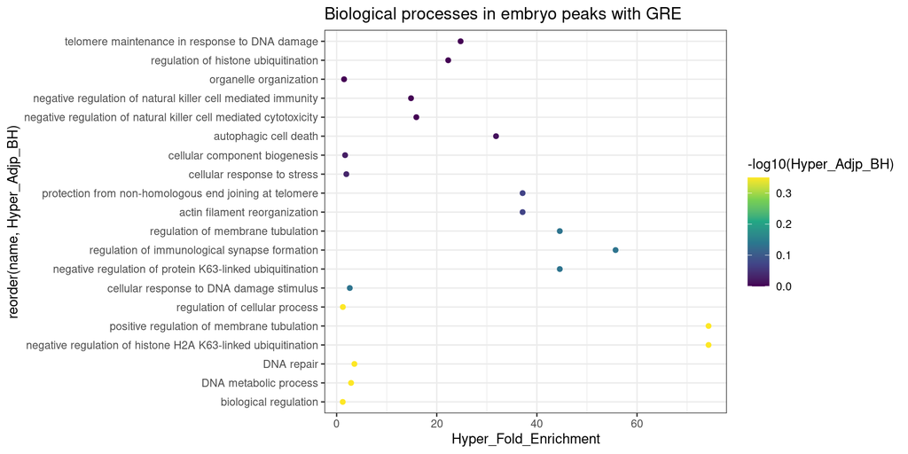

```r
job <- submitGreatJob(embryo_hc_peaks_mm10, species="mm10")
res <- getEnrichmentTables(job)

bp <- res$`GO Biological Process`
# head(bp)
write.table(bp, file = "./objects//GO-analysis_biolprocess_hcembryoGRE.csv")

ggplot(head(bp,20), aes(Hyper_Fold_Enrichment, reorder(name, Hyper_Adjp_BH),  color=-log10(Hyper_Adjp_BH))) + geom_point() + scale_color_viridis_c() + ggtitle("Biological processes in embryo peaks with GRE")
```

```r
ggsave("./sup_plots/FigS3A_GO-term_enrichment_BiologicalProcess_embryo_GREhighconfidencepeaks.png")
ggsave("./sup_plots/FigS3A_GO-term_enrichment_BiologicalProcess_embryo_GREhighconfidencepeaks.pdf")
ggsave("./sup_plots/FigS3A_GO-term_enrichment_BiologicalProcess_embryo_GREhighconfidencepeaks.svg")
```

# 32 Fig S3B - sperm GRE peaks across embryo tracks

```r
tracks_embryos <- c(
  embryoearly2cell="extern_data/ATAC_PRJNA277362_Early2cell_merged.bw",
  embryo2cell="extern_data/ATAC_PRJNA277362_2cell_merged.bw",
  embryo4cell="extern_data/ATAC_PRJNA277362_4cell_merged.bw",
  ESC="extern_data/ATAC_PRJNA277362_ESC_GSM1625858.bw")

peaks <- readRDS("objects/peaks_with_GRE_sperm.rds")




m <- signal2Matrix(tracks_embryos, peaks, w=20, BPPARAM = 4)
m <- epiwraps:::.ese2ml(m)
n <- renormalizeBorders(lapply(m, log1p))


pdf("sup_plots/FigS3B_GREpeaks-sperm-embryotracks.pdf")
x <- plotEnrichedHeatmaps(n, row_title="Peaks from sperm with GRE", trim = 0.99, raster_resize_mat = TRUE)
print(x)
dev.off()


png("sup_plots/FigS3B_GREpeaks-sperm-embryotracks.png", width=1024, height=768)
x <- plotEnrichedHeatmaps(n, row_title="Peaks from sperm with GRE", trim = 0.99, raster_resize_mat = TRUE)
print(x)
dev.off()

print(x)
```

[output not shown]

# 33 Fig S3C - GSEA of DEGs

```r
deaGO <- function(dea, threshold=0.05, direction=NULL, ontology="BP"){
  isDE <- dea$adj.P.Val<threshold
  if(!is.null(direction)) isDE <- isDE & sign(dea$logFC)==sign(direction)
  isDE <- setNames(factor(as.integer(isDE)),row.names(dea))
  print(table(isDE))
  god <- new("topGOdata", ontology=ontology, allGenes=isDE,
             nodeSize=10, annot=annFUN.org,
             ID="symbol", mapping="org.Mm.eg.db")
  ea <- runTest(god, algorithm="classic", statistic="fisher")
  res <- GenTable(god, classicFisher=ea, topNodes=length(god@graph@nodes))
  res$Term2 <- plgINS::breakStrings(res$Term)
  res$log2Enrichment <- log2(res$Significant/res$Expected)
  res$FDR <- p.adjust(res$classicFisher)
  res
}

deaGSEA <- function(dea, gsets=NULL){
  if(is.null(gsets))
    gsets <- plgINS::getMsigSets("Mus musculus", collections=c("H","C5"))
  signature <- setNames(sign(dea$logFC)*-log10(dea$P.Value), row.names(dea))
  fg <- fgseaMultilevel(gsets, signature, minSize=10, nproc=3)
  fg$genes <- sapply(fg$leadingEdge, collapse=", ", FUN=paste)
  fg$leadingEdge <- NULL
  as.data.frame(fg[order(fg$pval),])
}
```

for 2-cell

```r
se <- readRDS("objects/MK_EXP20.1_ProtacEmbryo_merged.SE.rds")

deas <- getDEA(se)
dea <- deas$PROTAC
```

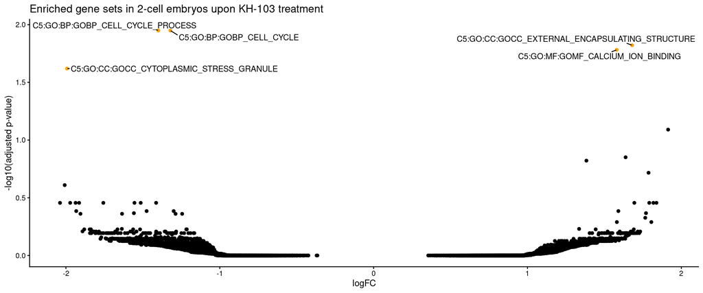

```r
res2 <- readRDS("objects/GSEA_2cell.rds")

generate_volcano_plot <- function(df, title) {
  df$highlight <- df$padj < 0.05
  ggplot(df, aes(x=NES, y=-log10(padj))) +
    geom_point(aes(color = highlight)) +
    scale_color_manual(values = c("TRUE" = "orange", "FALSE" = "black")) +
    geom_text_repel(data = subset(df, highlight == TRUE), aes(label=pathway), size=3.5, min.segment.length = 0) +
    xlab("logFC") +
    ylab("-log10(adjusted p-value)") +
    theme_classic() +
    theme(legend.position="none") +
    ggtitle(title)
}
generate_volcano_plot(res2, "Enriched gene sets in 2-cell embryos upon KH-103 treatment")
```

```r
# ggsave("plots/GSEA_EXP20-1_PROTAC.svg")
# ggsave("plots/GSEA_EXP20-1_PROTAC.pdf")
# ggsave("plots/GSEA_EXP20-1_PROTAC.png")
```

alternative plot

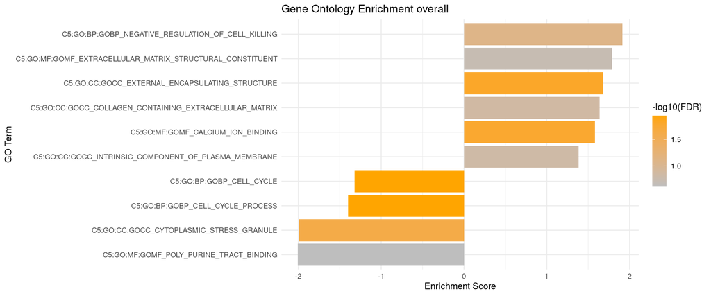

```r
ggplot(head(res2,10), aes(x = reorder(pathway, NES), y = NES, fill = -log10(padj))) +
  geom_bar(stat = "identity") +
  coord_flip() +
  scale_fill_gradient(low = "grey", high = "orange") +
  theme_minimal() +
  labs(
    title = "Gene Ontology Enrichment overall",
    x = "GO Term",
    y = "Enrichment Score",
    fill = "-log10(FDR)"
  )
```

for 8-cell

```r
se <- readRDS("objects/MK_EXP20.2_ProtacEmbryo8cells.SE.rds")

deas <- getDEA(se)
dea <- deas$PROTAC
```

```r
res4 <- deaGSEA(dea)
# res4

#saveRDS(res4, "GSEA_8cell.rds")
```

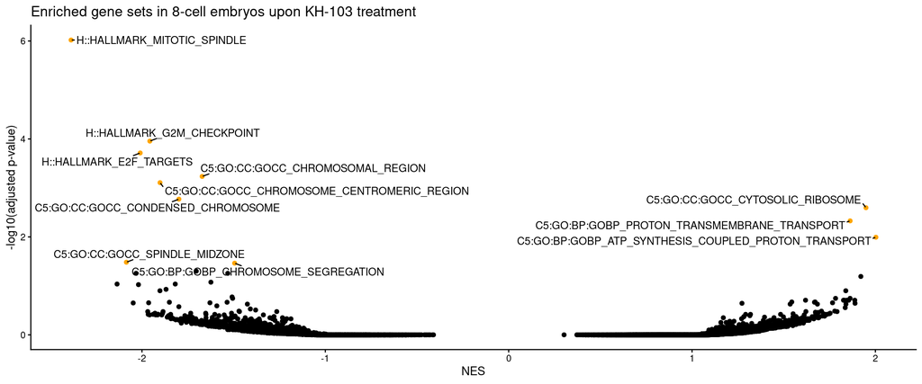

```r
res4 <- readRDS("objects/GSEA_8cell.rds")
generate_volcano_plot <- function(df, title) {
  df$highlight <- df$padj < 0.05
  ggplot(df, aes(x=NES, y=-log10(padj))) +
    geom_point(aes(color = highlight)) +
    scale_color_manual(values = c("TRUE" = "orange", "FALSE" = "black")) +
    geom_text_repel(data = subset(df, highlight == TRUE), aes(label=pathway), size=3.5, min.segment.length = 0) +
    xlab("NES") +
    ylab("-log10(adjusted p-value)") +
    theme_classic() +
    theme(legend.position="none") +
    ggtitle(title)
}
generate_volcano_plot(res4, "Enriched gene sets in 8-cell embryos upon KH-103 treatment")
```

```r
ggsave("sup_plots/FigS3C_GSEA_EXP20-2_PROTAC.svg")
ggsave("sup_plots/FigS3C_GSEA_EXP20-2_PROTAC.pdf")
ggsave("sup_plots/FigS3C_GSEA_EXP20-2_PROTAC.png")
```

# 34 Fig 4E - 2cell Smartseq after Dex treatment in sperm and Fig S4F - 2cell Smartseq after KH-103 treatment in sperm

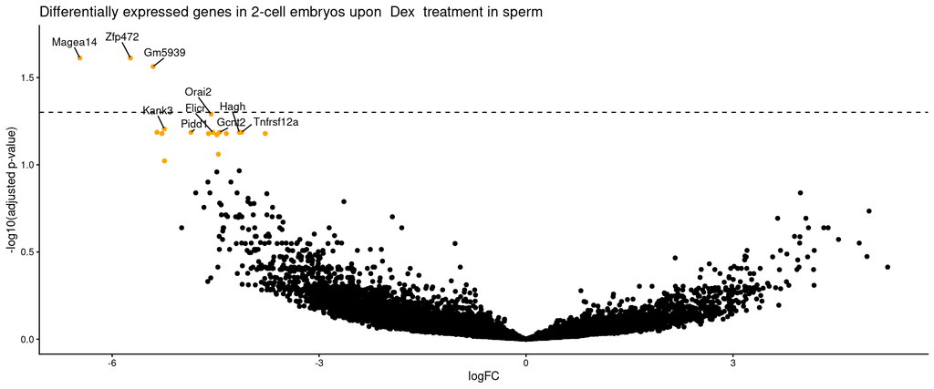

```r
generate_volcano_plot <- function(df, title) {
  df$highlight <- df$adj.P.Val < 0.1
  top_genes <- df[order(df$adj.P.Val), ][1:10, ]
  ggplot(df, aes(x=logFC, y=-log10(adj.P.Val))) +
    geom_point(aes(color = highlight)) +
    scale_color_manual(values = c("TRUE" = "orange", "FALSE" = "black")) +
    geom_text_repel(data = subset(top_genes, highlight == TRUE), aes(label=Gene), size=3.5, min.segment.length = 0, max.overlaps = Inf, nudge_y = 0.1) +
    geom_hline(yintercept=-log10(0.05), linetype="dashed")+
    xlab("logFC") +
    ylab("-log10(adjusted p-value)") +
    theme_classic() +
    theme(legend.position="none") +
    ggtitle(title)
}

se <- readRDS("objects/MK_EXP16.4_embryoSeq_spermProtac_merged.SE.rds")

# Generate the dataframes
dex <- rowData(se)[[4]]
protac <- rowData(se)[[3]]
pd <- rowData(se)[[5]]

protac$Gene <- rownames(protac)
dex$Gene <- rownames(dex)
pd$Gene <- rownames(pd)

# List of dataframes
df_list <- list(Dex = dex, "KH-103" = protac, "KH-103+Dex" = pd)

# Apply the function to each dataframe in the list
plots <- lapply(names(df_list), function(name) {
  generate_volcano_plot(df_list[[name]], paste("Differentially expressed genes in 2-cell embryos upon ", name, " treatment in sperm"))
})
print(plots[1])
```

```r
ggsave("plots/Fig4E_DEGs_EXP16-4_Dex_volcano.svg")
ggsave("plots/Fig4E_DEGs_EXP16-4_Dex_volcano.pdf")
ggsave("plots/Fig4E_DEGs_EXP16-4_Dex_volcano.png")

# print(plots[2])
# ggsave("plots/DEGs_EXP16-4_PROTAC_volcano.svg")
# ggsave("plots/DEGs_EXP16-4_PROTAC_volcano.pdf")
# ggsave("plots/DEGs_EXP16-4_PROTAC_volcano.png")
#
# print(plots[3])
# ggsave("plots/DEGs_EXP16-4_PD_volcano.svg")
# ggsave("plots/DEGs_EXP16-4_PD_volcano.pdf")
# ggsave("plots/DEGs_EXP16-4_PD_volcano.png")
```

# 35 Fig 4F - Reversal of Dex by KH-103

Can we see reversal for genes not passing significance?

```r
se <- readRDS("objects/MK_EXP16.4_embryoSeq_spermProtac_merged.SE.rds")
se <- se[, se$treatment != "MED"]
rescue <- rowData(se)[[6]]
rescue$Gene <- rownames(rescue)

rescue_sorted <- rescue[order(rescue$adj.P.Val), ]
rescue_sorted <- rescue_sorted[1:20, ]

treatments <- unique(se$treatment)

# Define your own colors
colors <- c(brewer.pal(9,"Set2")[3], "grey", "orange", brewer.pal(9,"Set2")[5] )#"#0000FF", "#800080", "grey", "black")

# Make sure the number of colors matches the number of treatments
if (length(colors) != length(treatments)) {
  stop("Number of colors must match number of treatments")
}

colors <- c("#919297", "#DEDFE4", "darkgrey", "#393A3F")
# Create a named vector for color mapping
color_mapping <- setNames(colors, treatments)

# Add color_mapping to the heatmap annotation
ha = HeatmapAnnotation(df = data.frame(treatment = factor(colData(se)$treatment, levels = names(color_mapping))),
                       col = list(treatment = color_mapping))

#sechm(se, rescue_sorted, assayName = "log2FC", do.scale = FALSE, top_annotation = ha, row_title="KH103-mediated\nrescue of DEX effect", gaps_at="treatment")
#needs title: Effects of KH-103 treatment in sperm on gene regulation in 2-cell embryos


color_palette <- colorRampPalette(c("blue", "black", "orange"))(10000)

pdf("plots/Fig4F_DEGs_EXP16-4_rescue_heatmap.pdf", width=6, height=4) #, width=14.5, height=10)
x <- sechm(se, rescue_sorted, assayName = "log2FC", do.scale = FALSE, top_annotation = ha, row_title="KH103-mediated\nrescue of DEX effect", gaps_at="treatment", hmcols = color_palette, use_raster = TRUE)
print(x)
dev.off()
```

```r
png("plots/Fig4F_DEGs_EXP16-4_rescue_heatmap.png")#, height=768)
x <- sechm(se, rescue_sorted, assayName = "log2FC", do.scale = FALSE, top_annotation = ha, row_title="KH103-mediated\nrescue of DEX effect", gaps_at="treatment", hmcols = color_palette, use_raster = TRUE)
print(x)
dev.off()
```

```r
svg("plots/Fig4F_DEGs_EXP16-4_rescue_heatmap.svg")#, height=768)
x <- sechm(se, rescue_sorted, assayName = "log2FC", do.scale = FALSE, top_annotation = ha, row_title="KH103-mediated\nrescue of DEX effect", gaps_at="treatment", hmcols = color_palette, use_raster = TRUE)
print(x)
dev.off()
```

```r
# rescue_sorted

sechm(se, rescue_sorted, assayName = "log2FC", do.scale = FALSE, top_annotation = ha, row_title="Differentially expressed genes", gaps_at="treatment", hmcols = color_palette, use_raster = TRUE)
```

[output not shown]

# 36 Fig S4J - RegionUpset

```r
df <- read.csv("objects/DEA_rescueDEGs_Fig4_venn_categories.csv", sep = ";")
# Create a list of vectors, each vector represents a category
sperm_overlaps <- df$Gene[df$Overlap.sperm.ATAC == 1]
gre <- df$Gene[df$GRE.in.gene == 1]
motifs <- df$Gene[df$gene.body.motifs.connected.to.GR == 1]

gene_list <- list(DEGs = df$Gene, "DEGs accesible in Sperm" = sperm_overlaps, "DEGs with GRE motif" = gre, "DEGs with GR binding partner motif" = motifs)
```

```r
upset <- regionUpset2(gene_list,returnList = T)
```

```r
png(paste0("sup_plots/FigS4J_rescue.png"),width=8, height=7,res = 300,units = "in")
regionUpset2(gene_list)
dev.off()
```

```r
pdf(paste0("sup_plots/FigS4J_rescue.pdf"), width=8, height=7,colormodel = "cymk")
regionUpset2(gene_list)
dev.off()
```

```r
svg(paste0("sup_plots/FigS4J_rescue.svg"), width=8, height=7)
regionUpset2(gene_list)
dev.off()
```

# 37 Fig S4K - 2cell volcano

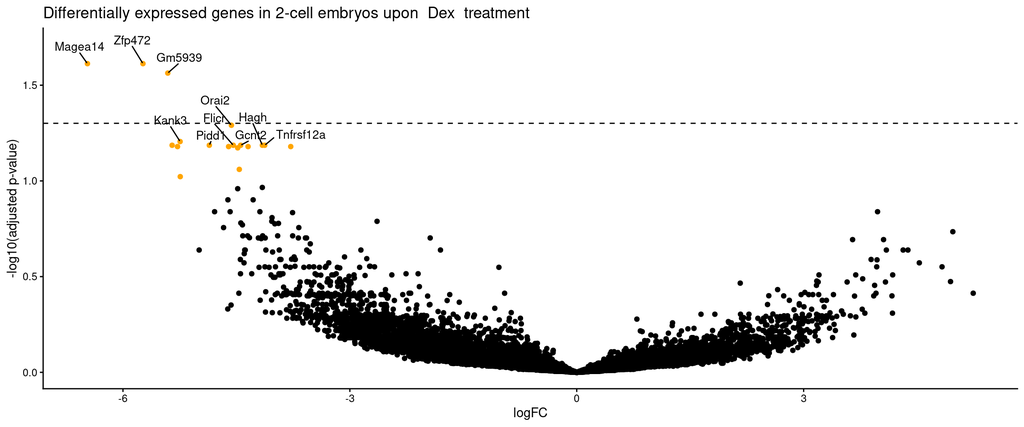

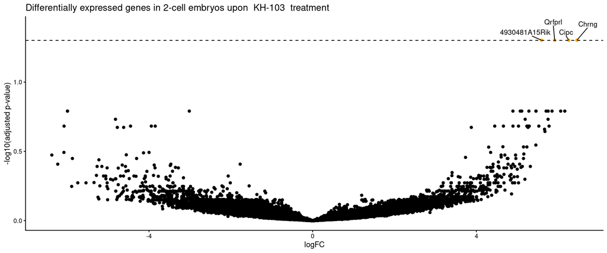

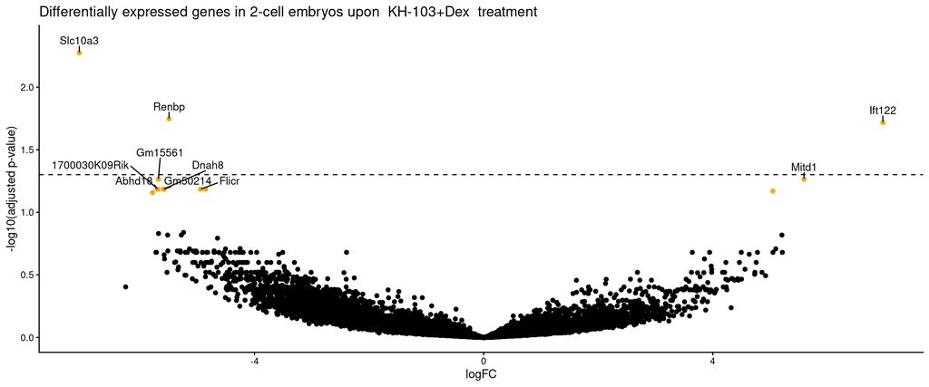

```r
se <- readRDS("objects/MK_EXP16.4_embryoSeq_spermProtac_merged.SE.rds")

# Generate the dataframes
dex <- rowData(se)[[4]]
protac <- rowData(se)[[3]]
pd <- rowData(se)[[5]]

protac$Gene <- rownames(protac)
dex$Gene <- rownames(dex)
pd$Gene <- rownames(pd)

# List of dataframes
df_list <- list(Dex = dex, "KH-103" = protac, "KH-103+Dex" = pd)

# Function to generate volcano plots
generate_volcano_plot <- function(df, title) {
  df$highlight <- df$adj.P.Val < 0.1
  top_genes <- df[order(df$adj.P.Val), ][1:10, ]
  ggplot(df, aes(x=logFC, y=-log10(adj.P.Val))) +
    geom_point(aes(color = highlight)) +
    scale_color_manual(values = c("TRUE" = "orange", "FALSE" = "black")) +
    geom_text_repel(data = subset(top_genes, highlight == TRUE), aes(label=Gene), size=3.5, min.segment.length = 0, max.overlaps = Inf, nudge_y = 0.1) +
    geom_hline(yintercept=-log10(0.05), linetype="dashed")+
    xlab("logFC") +
    ylab("-log10(adjusted p-value)") +
    theme_classic() +
    theme(legend.position="none") +
    ggtitle(title)
}

# Apply the function to each dataframe in the list
plots <- lapply(names(df_list), function(name) {
  generate_volcano_plot(df_list[[name]], paste("Differentially expressed genes in 2-cell embryos upon ", name, " treatment"))
})

print(plots)
```

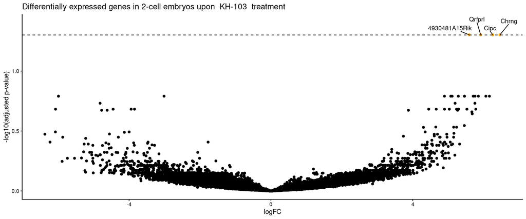

```r
# print(plots[1])
# ggsave("plots/DEGs_EXP20-1_Dex_volcano.svg")
# ggsave("plots/DEGs_EXP20-1_Dex_volcano.pdf")
# ggsave("plots/DEGs_EXP20-1_Dex_volcano.png")

print(plots[2])
```

```r
ggsave("sup_plots/FigS4K_DEGs_sperm_PROTAC_volcano.svg")
ggsave("sup_plots/FigS4K_DEGs_sperm_PROTAC_volcano.pdf")
ggsave("sup_plots/FigS4K_DEGs_sperm_PROTAC_volcano.png")

# print(plots[3])
# ggsave("plots/DEGs_EXP20-1_PD_volcano.svg")
# ggsave("plots/DEGs_EXP20-1_PD_volcano.pdf")
# ggsave("plots/DEGs_EXP20-1_PD_volcano.png")
```

#Fig S4L - correlation with PGC-GR-KO

Calculate correaltion and visualize with scatterplot

```r
KO <- readRDS("objects/VF_2cell_embyro_early_paternal_GR_KO(Alpl).SE.rds")
KO <- rowData(KO)[[2]]
koFDR <- subset(KO, KO$FDR <0.05)
koFDR$Gene <- koFDR$ID


se <- readRDS("objects/SEs_for_SEV/MK_EXP16.4_embryoSeq_spermProtac_merged.SE.rds")
```

```
## Error in `gzfile()`:
## ! cannot open the connection
```

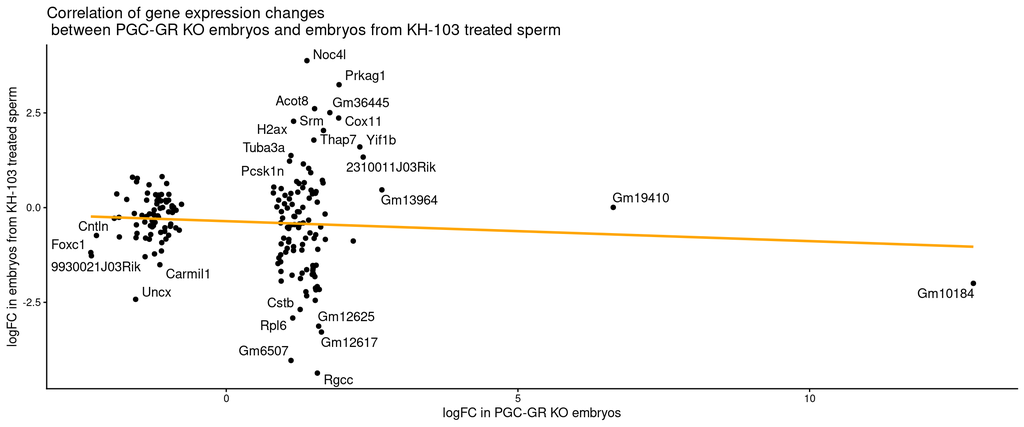

```r
protac <- rowData(se)[[3]]
protac$Gene <- rownames(protac)


merged_data <- merge(koFDR, protac, by.x = "ID", by.y = "Gene")

correlation <- cor.test(merged_data$logFC.x, merged_data$logFC.y)
# correlation

# Create a scatter plot to visualize the correlation
plot <- ggplot(merged_data, aes(x=logFC.x, y=logFC.y)) +
    geom_point() +
    geom_text_repel(aes(label=Gene)) +  # Add the gene names to the plot
    geom_smooth(method=lm, se=FALSE, color="orange") +
    #annotate("text", x = Inf, y = -Inf, label = paste("Correlation:", correlation)) +#, vjust = -1.5, hjust = 1.2) +
    xlab(paste("logFC in PGC-GR KO embryos")) +
    ylab(paste("logFC in embryos from KH-103 treated sperm")) +
    ggtitle(paste("Correlation of gene expression changes \n between PGC-GR KO embryos and embryos from KH-103 treated sperm"))+
    theme_classic()

print(plot)
```

```r
ggsave("sup_plots/FigS4L_correlation_VF-KO_EXP16-4_PROTAC.svg")
ggsave("sup_plots/FigS4L_correlation_VF-KO_EXP16-4_PROTAC.pdf")
ggsave("sup_plots/FigS4L_correlation_VF-KO_EXP16-4_PROTAC.png")
```

# 38 Fig 5B F0 Transition through center

```r
# load data
report_tracking <- read.csv("objects/OFT_Report.csv",sep = ";")
report_tracking <- data.frame(report_tracking)

meta <- openxlsx::read.xlsx("objects/stressed_males_OFT_metadata.xlsx") # check if everything is right

# check if order is right
report_tracking$file == meta$OFTfile
```

```
##  [1]  TRUE FALSE FALSE FALSE FALSE FALSE FALSE FALSE FALSE FALSE FALSE FALSE
## [13] FALSE FALSE FALSE FALSE FALSE FALSE FALSE FALSE FALSE FALSE FALSE FALSE
## [25] FALSE FALSE FALSE FALSE FALSE FALSE
```

```r
# if not change order of meta file
report_tracking$file == meta[order(meta$OFTfile),]$OFTfile
```

```
##  [1] TRUE TRUE TRUE TRUE TRUE TRUE TRUE TRUE TRUE TRUE TRUE TRUE TRUE TRUE TRUE
## [16] TRUE TRUE TRUE TRUE TRUE TRUE TRUE TRUE TRUE TRUE TRUE TRUE TRUE TRUE TRUE
```

```r
report_tracking$condition <- meta[order(meta$OFTfile),]$condition

#Relabel "IFS" as "Stress"

report_tracking$condition <- factor(report_tracking$condition,
                                    levels = c("Control", "IFS"),
                                    labels = c("Control", "Stress"))
```

```r
theme_set(theme_classic())
```

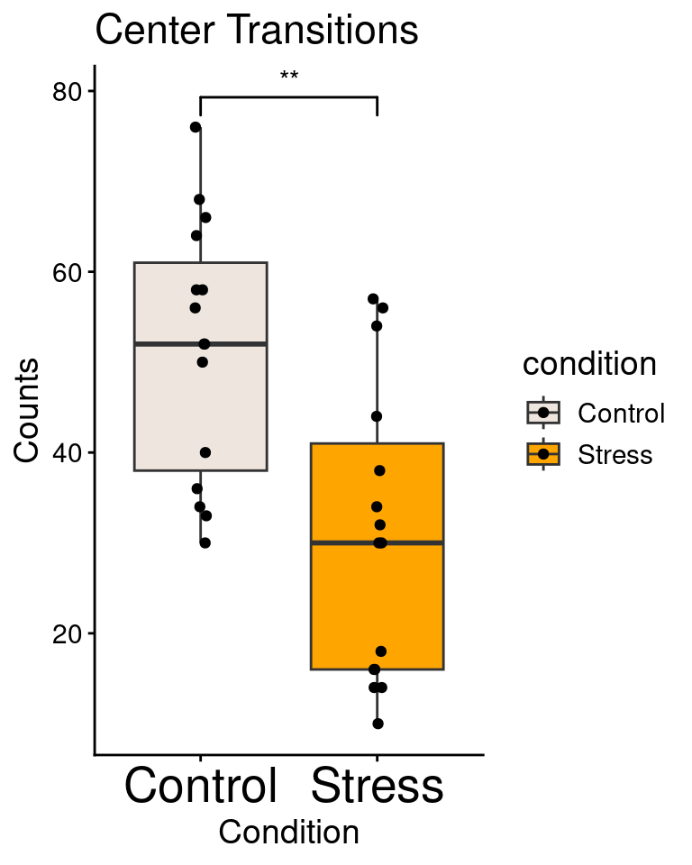

```r
e <- ggplot(report_tracking, aes(x = condition, y = bodycentre.center.transitions, fill=condition))
cols <- c("seashell2", "#ffa500ff")

e2 <- e +
  geom_boxplot(width = 0.75, outlier.shape = NA) +
  geom_jitter(position = position_jitterdodge(jitter.width = 0.1), dodge.width = 0.75) +
  #stat_summary(fun = mean, geom = "point", shape = 4, size = 3, color = "red", fill = "red") +
  geom_signif(comparisons = list(c("Control", "Stress")), map_signif_level = TRUE) +
  scale_fill_manual(values = cols) +
  labs(title = "Center Transitions") +
  ylab("Counts") +
  xlab("Condition") +
  theme_classic() +
  theme(
    axis.text.x = element_text(size = 20),
    text = element_text(size = 14)
  )

print(e2)
```

```r
ggsave("plots/Fig5B.Transitions.png")
ggsave("plots/Fig5B.Transitions.pdf")
ggsave("plots/Fig5B.Transitions.svg")
```

# 39 Fig 5C Baseline Cort difference F0

```r
cort_df <- data.frame(Condition = c(rep("Control",8),rep("Stress",8)),
           Cort = c(34.83,  41.514, 24.323, 31.654, 27.842, 60.724, 52.208, 53.683, 70.372, 40.766, 36.163, 89.217, 61.647, 42.545, 47.178, 76.72)) # 1 week after IFS
```

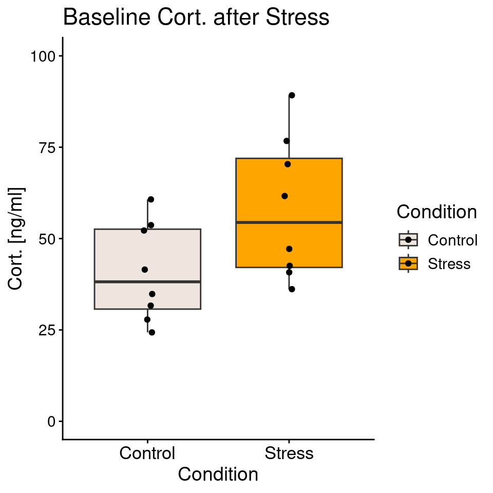

```r
  e <- ggplot(cort_df, aes(x = Condition, y = Cort, fill = Condition))


 e2 <- e + geom_boxplot(width = 0.75,outlier.shape = NA ) +
   geom_jitter(
   position=position_jitterdodge(jitter.width = 0.1, dodge.width = 0.75)
    )+
   ylab("Cort. [ng/ml]")+
   xlab("Condition")+
   ggtitle("Baseline Cort. after Stress")+
   scale_fill_manual(values=c( "seashell2","#ffa500ff"))+
   labs(fill= "Condition")+
   ylim(c(0,100))+

 theme(
  axis.text.x = element_text(size = 13),
  text = element_text(size = 14)
)


 print(e2)
```

```r
 ggsave("plots/Fig5C.StressedAnimalsBaselineCort.png")
  ggsave("plots/Fig5C.StressedAnimalsBaselineCort.pdf")
   ggsave("plots/Fig5C.StressedAnimalsBaselineCort.svg")
```

## 39.1 20min after

```r
df <- openxlsx::read.xlsx("objects/PostIFS20min.xlsx")
df$Condition <- factor(df$Condition,levels = c("CTRL","IFS"),labels = c("Control","Stress"))
```

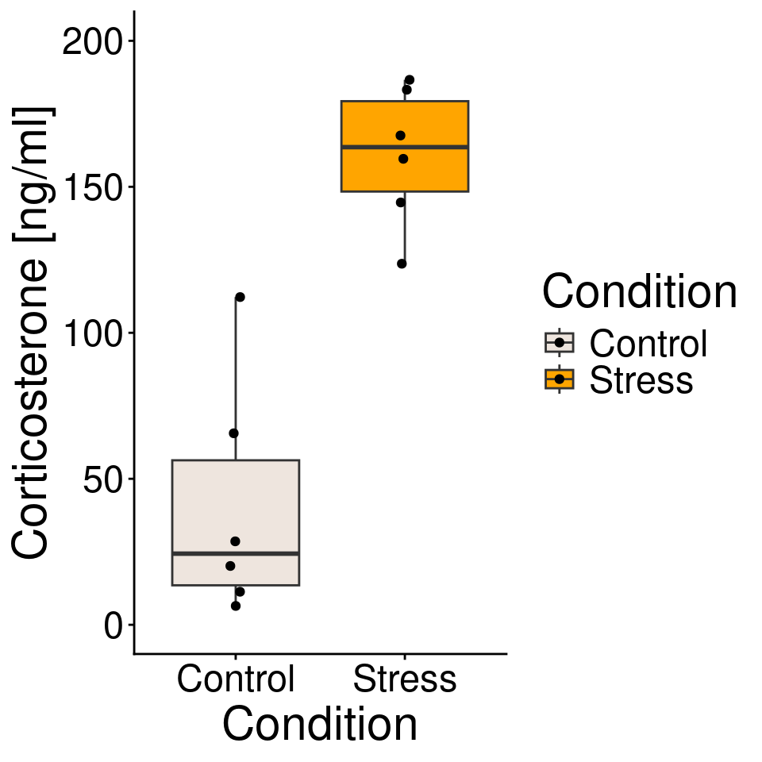

```r
  e <- ggplot(df, aes(x = Condition, y = df$`ng/mL`, fill = Condition))


 e2 <- e + geom_boxplot(width = 0.75,outlier.shape = NA ) +
   geom_jitter(
   position=position_jitterdodge(jitter.width = 0.1, dodge.width = 0.75)
    )+
    ylab("Corticosterone [ng/ml]")+
   xlab("Condition")+
   # ggtitle("Baseline Cort. after Stress")+
   scale_fill_manual(values=c( "seashell2","#ffa500ff"))+
   labs(fill= "Condition")+
    ylim(c(0,200))+
   theme_classic()+

 theme(
  # axis.text.x = element_text(size = 13),
  text = element_text(size = 22)
)


 print(e2)
```

```r
 # ggsave("plots/Fig5C.StressedAnimalsBaselineCort.png")
  ggsave("plots/Fig5C.StressedAnimalsBaselineCort20min.pdf")
    # ggsave("plots/Fig5C.StressedAnimalsBaselineCort.svg")
```